# Forecasting Median Listing Price - Rhode Island

STAT 645 Time Series Forecasting - Final Project

Group X

June 04, 2026

# 1. The data

We forecast the FRED series **MEDLISPRIRI** - the monthly median listing price (USD) of homes in **Rhode Island**. The data are sourced by FRED from Zillow, span **July 2016 through March 2026** (117 monthly observations), and capture both the 2020 - 2024 housing boom and the recent softening.

```r
raw <- read_excel("MEDLISPRIRI.xlsx", sheet = "Monthly")
names(raw) <- c("date", "price")

price_ts <- raw |>
  mutate(month = yearmonth(date)) |>
  as_tsibble(index = month) |>
  select(month, price)

price_ts |> head()
```

| month | price |
| --- | --- |
| 2016 Jul | 329900 |
| 2016 Aug | 329450 |
| 2016 Sep | 329000 |
| 2016 Oct | 325000 |
| 2016 Nov | 320000 |
| 2016 Dec | 314900 |

```r
tibble(
  n           = nrow(price_ts),
  start       = format(min(price_ts$month)),
  end         = format(max(price_ts$month)),
  has_gaps    = any(has_gaps(price_ts)$.gaps),
  min_price   = min(price_ts$price),
  max_price   = max(price_ts$price),
  mean_price  = round(mean(price_ts$price))
) |> kable()
```

| n | start | end | has_gaps | min_price | max_price | mean_price |
| --- | --- | --- | --- | --- | --- | --- |
| 117 | 2016 Jul | 2026 Mar | FALSE | 314225 | 599450 | 438104 |

## 1.1 Time-series plot

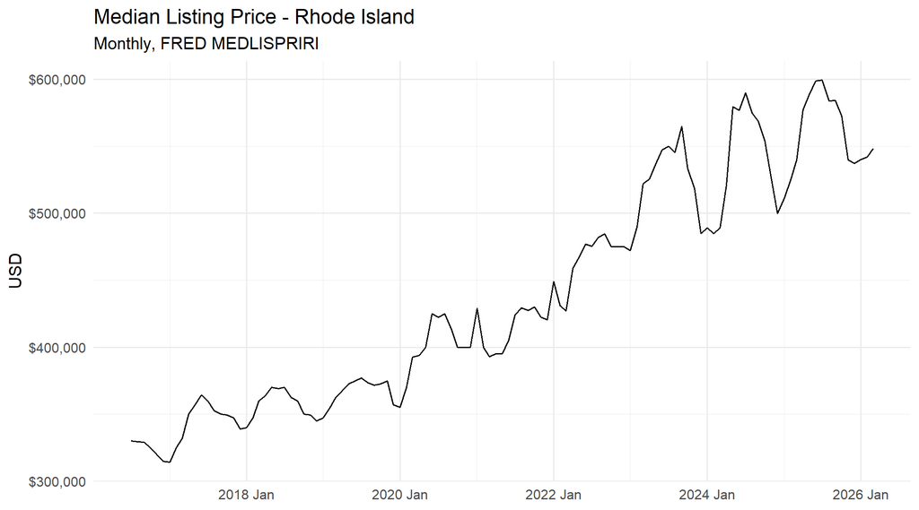

```r
p_overview <- price_ts |>
  autoplot(price) +
  labs(title = "Median Listing Price - Rhode Island",
       subtitle = "Monthly, FRED MEDLISPRIRI",
       x = NULL, y = "USD") +
  scale_y_continuous(labels = scales::label_dollar())
save_png(p_overview, "01_overview.png")
p_overview
```

The series shows a strong upward trend, a noticeable acceleration around 2020, a peak near mid-2025, and a recent decline. A multiplicative seasonal pattern (variance growing with the level) is plausible, which we test below.

## 1.2 Seasonality

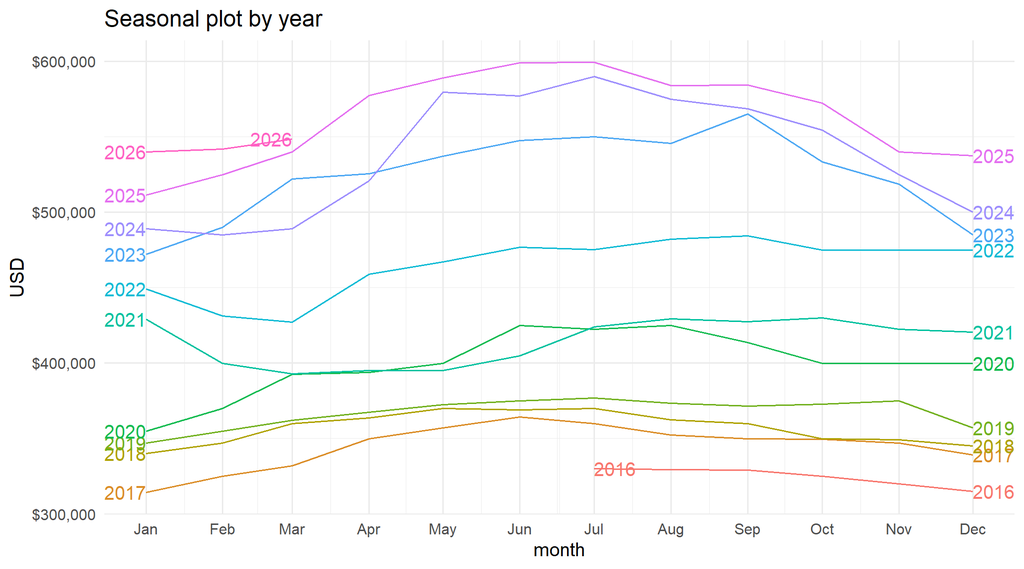

```r
p_season <- price_ts |>
  gg_season(price, labels = "both") +
  labs(title = "Seasonal plot by year", y = "USD") +
  scale_y_continuous(labels = scales::label_dollar())
save_png(p_season, "02_seasonality.png")
p_season
```

Most years show a familiar housing rhythm - prices climbing into the spring/summer listing window, then easing toward year-end. The amplitude is small relative to the trend but consistent enough to model.

## 1.3 STL decomposition

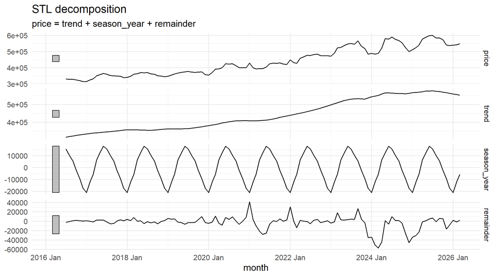

```r
stl_comp <- price_ts |>
  model(STL(price ~ trend(window = 13) + season(window = "periodic"),
            robust = TRUE)) |>
  components()

p_stl <- autoplot(stl_comp) +
  labs(title = "STL decomposition")
save_png(p_stl, "03_stl.png", w = 9, h = 7)
p_stl
```

## 1.4 Transformation check

The spread of the series grows with its level, so a variance-stabilising transform is worth considering. The Guerrero-optimal Box-Cox lambda is:

```r
lambda <- price_ts |>
  features(price, features = guerrero) |>
  pull(lambda_guerrero)
sprintf("Guerrero lambda: %.3f", lambda)
```

```
## [1] "Guerrero lambda: -0.900"
```

The optimum (lambda approximately -0.9) is extreme and numerically unstable on a short series with a structural break - a Box-Cox ETS at this lambda back-transforms to non-finite forecasts. We therefore use a **log** transform (lambda = 0) for the transformed ETS candidate: it stabilises the variance cleanly and, because the transform is fixed rather than estimated from the data, it introduces no holdout leakage.

# 2. Train / test split

We hold out the **last 12 months** (~10% of n=117). All candidate models are fit on the training portion and evaluated on the holdout.

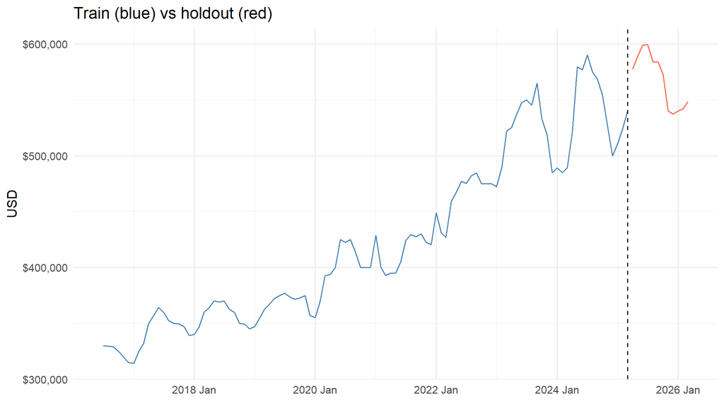

```r
h_test <- 12
cutoff <- max(price_ts$month) - h_test
train  <- price_ts |> filter(month <= cutoff)
test   <- price_ts |> filter(month >  cutoff)

p_split <- ggplot() +
  geom_line(data = train, aes(month, price), colour = "steelblue") +
  geom_line(data = test,  aes(month, price), colour = "tomato") +
  geom_vline(xintercept = as.Date(cutoff), linetype = 2) +
  scale_y_continuous(labels = scales::label_dollar()) +
  labs(title = "Train (blue) vs holdout (red)",
       x = NULL, y = "USD")
save_png(p_split, "04_train_test.png")
p_split
```

# 3. Candidate models

We fit twelve candidates spanning every model family covered in class:

- **Toolbox baselines** - `MEAN`, `NAIVE`, `SNAIVE`, `RW + drift`
- **Time-series linear regression (TSLM)** - trend + seasonal dummies, and trend + Fourier(K=2)
- **ETS (exponential smoothing)** - hand-specified M-A-M, damped A-Ad-A, and a log-transformed ETS
- **ARIMA** - automatically selected, plus a hand-specified seasonal `(1,1,1)(0,1,1)`
- **STL decomposition + ETS** on the seasonally adjusted series

```r
fits <- train |>
  model(
    Mean       = MEAN(price),
    Naive      = NAIVE(price),
    SNaive     = SNAIVE(price ~ lag("year")),
    Drift      = RW(price ~ drift()),
    TSLM_seas  = TSLM(price ~ trend() + season()),
    TSLM_four  = TSLM(price ~ trend() + fourier(K = 2)),
    ETS_MAM    = ETS(price ~ error("M") + trend("A")  + season("M")),
    ETS_AAdA   = ETS(price ~ error("A") + trend("Ad") + season("A")),
    ETS_log    = ETS(log(price)),
    ARIMA      = ARIMA(price),
    ARIMA_man  = ARIMA(price ~ pdq(1, 1, 1) + PDQ(0, 1, 1)),
    STL_ETS    = decomposition_model(
                   STL(price ~ trend(window = 13) +
                                season(window = "periodic"),
                       robust = TRUE),
                   ETS(season_adjust ~ season("N"))
                 )
  )
```

```r
train |> model(ETS_auto = ETS(price), ARIMA_auto = ARIMA(price))
```

[output not shown]

```r
# glance() does not support decomposition_model; exclude STL_ETS here.
# AICc is comparable WITHIN the ETS and ARIMA families, but not across
# families or against TSLM, so selection is made on holdout accuracy.
glance(fits |> select(-STL_ETS)) |>
  select(.model, AIC, AICc, BIC, sigma2) |>
  arrange(AICc) |>
  kable(digits = 1, caption = "In-sample fit summary (STL_ETS excluded - no glance method)")
```

In-sample fit summary (STL_ETS excluded - no glance method)

| .model | AIC | AICc | BIC | sigma2 |
| --- | --- | --- | --- | --- |
| ETS_log | -258.8 | -250.9 | -211.1 | 0 |
| ARIMA_man | 2020.6 | 2021.0 | 2030.7 | 173783350 |
| TSLM_four | 2109.7 | 2110.8 | 2128.2 | 493716104 |
| TSLM_seas | 2122.9 | 2127.5 | 2160.0 | 527353772 |
| ARIMA | 2272.7 | 2273.0 | 2280.7 | 172697292 |
| ETS_MAM | 2464.8 | 2471.9 | 2509.9 | 0 |
| ETS_AAdA | 2485.7 | 2493.6 | 2533.5 | 154075740 |
| Mean | NA | NA | NA | 5821540510 |
| Naive | NA | NA | NA | 188600731 |
| SNaive | NA | NA | NA | 595916620 |
| Drift | NA | NA | NA | 188600731 |

# 4. Holdout accuracy

```r
fc_test <- fits |> forecast(h = h_test)

acc <- fc_test |>
  accuracy(price_ts) |>
  select(.model, RMSE, MAE, MAPE, MASE, RMSSE) |>
  arrange(RMSE)

write.csv(acc, file.path(fig_dir, "accuracy_table.csv"), row.names = FALSE)
acc |> kable(digits = c(0, 0, 0, 2, 2, 2),
             caption = "Forecast accuracy on the 12-month holdout, sorted by RMSE")
```

Forecast accuracy on the 12-month holdout, sorted by RMSE

| .model | RMSE | MAE | MAPE | MASE | RMSSE |
| --- | --- | --- | --- | --- | --- |
| ETS_MAM | 12658 | 11346 | 1.97 | 0.39 | 0.34 |
| ARIMA_man | 14021 | 12014 | 2.14 | 0.41 | 0.38 |
| TSLM_seas | 18694 | 17446 | 3.06 | 0.60 | 0.51 |
| TSLM_four | 18768 | 17484 | 3.06 | 0.60 | 0.51 |
| ARIMA | 18859 | 16934 | 2.93 | 0.58 | 0.51 |
| ETS_log | 19175 | 15817 | 2.72 | 0.54 | 0.52 |
| ETS_AAdA | 20952 | 17292 | 2.97 | 0.59 | 0.57 |
| SNaive | 24688 | 20552 | 3.65 | 0.70 | 0.67 |
| STL_ETS | 31253 | 28547 | 4.95 | 0.98 | 0.85 |
| Drift | 32930 | 30174 | 5.24 | 1.03 | 0.89 |
| Naive | 36394 | 28276 | 4.82 | 0.97 | 0.99 |
| Mean | 146366 | 144483 | 25.32 | 4.96 | 3.97 |

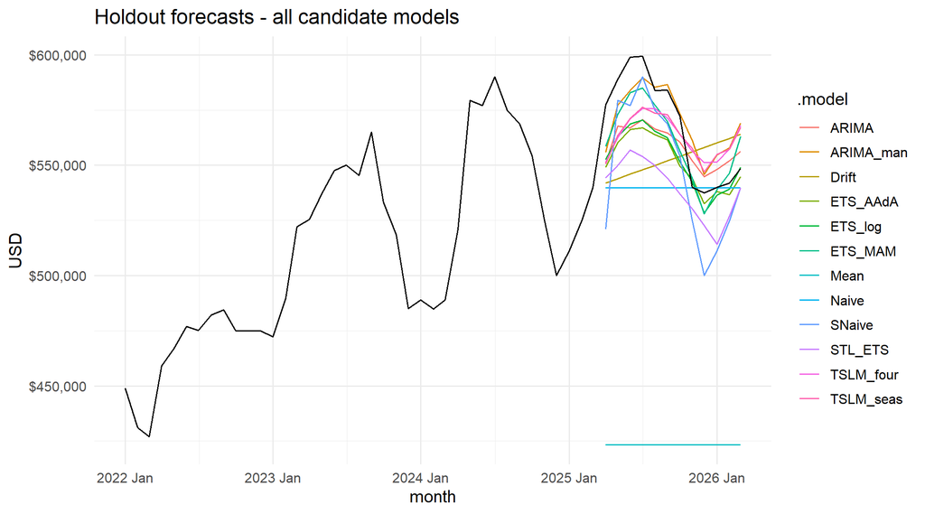

```r
p_compare <- fc_test |>
  autoplot(price_ts |> filter(month >= yearmonth("2022 Jan")),
           level = NULL) +
  labs(title = "Holdout forecasts - all candidate models",
       y = "USD") +
  scale_y_continuous(labels = scales::label_dollar())
save_png(p_compare, "05_forecasts_compare.png", w = 10, h = 5)
p_compare
```

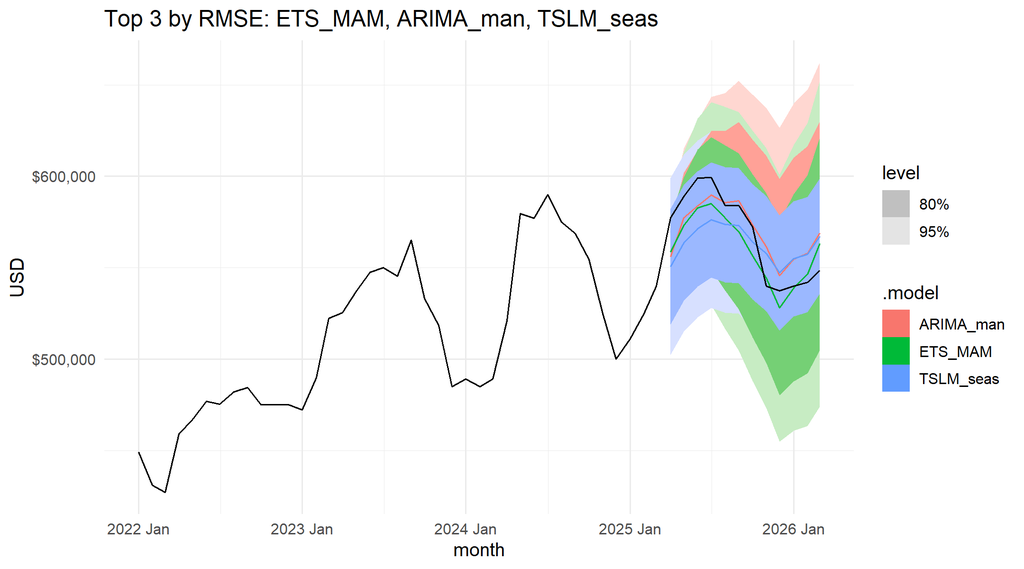

```r
best3 <- acc$.model[1:3]
p_best3 <- fc_test |>
  filter(.model %in% best3) |>
  autoplot(price_ts |> filter(month >= yearmonth("2022 Jan"))) +
  labs(title = paste("Top 3 by RMSE:", paste(best3, collapse = ", ")),
       y = "USD") +
  scale_y_continuous(labels = scales::label_dollar())
save_png(p_best3, "05b_best3_forecast.png", w = 10, h = 5)
p_best3
```

# 5. Judgment calls

A few non-obvious choices shaped the final pick:

1. **Holdout length.** Twelve months satisfies the rubric’s >=10% rule and exposes any model’s seasonal weakness across a full cycle.
2. **ARIMA family included.** Chapter 9’s ARIMA models are fit alongside ETS - both an auto-selected `ARIMA()` and a hand-specified seasonal `(1,1,1)(0,1,1)`. The seasonal ARIMA is the closest challenger to the winner, which confirms (rather than overturns) the ETS choice.
3. **Transformation.** The Guerrero lambda (approximately -0.9) is numerically unstable on this short, structurally-broken series, so the transformed candidate uses a log scale rather than a raw Box-Cox.
4. **Damped vs. non-damped trend.** The 2025 reversal makes an undamped trend dangerous for a 12-month forecast, so we include an A-Ad-A specification and let accuracy adjudicate.
5. **TSLM Fourier order.** K=2 captures the dominant annual cycle with four coefficients, fewer than the eleven implied by seasonal dummies and less prone to overfitting on a 105-month training set.

# 6. Residual diagnostics for the chosen model

```r
winner <- acc$.model[1]
winner
```

```
## [1] "ETS_MAM"
```

```r
best_fit <- fits |> select(all_of(winner))
```

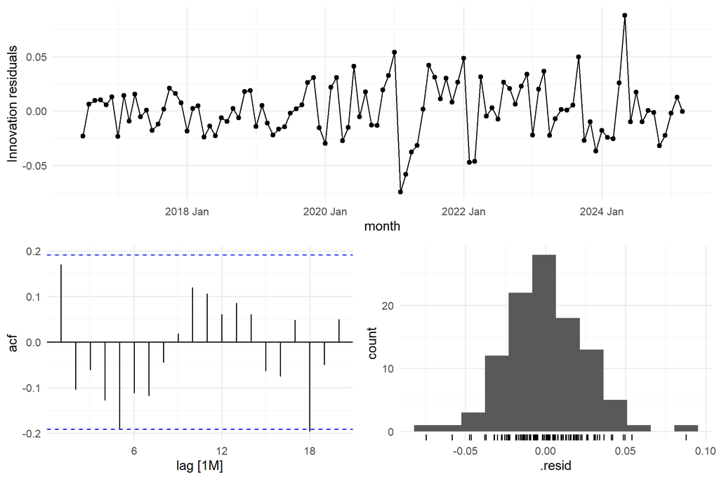

```r
p_resid <- best_fit |> gg_tsresiduals()
save_png(p_resid, "06_residuals.png", w = 9, h = 6)
p_resid
```

```r
# Degrees of freedom tied to the chosen model's estimated parameters
# (smoothing parameters + initial states for ETS), not a hardcoded 0.
n_par <- nrow(tidy(best_fit))
augment(best_fit) |>
  features(.innov, ljung_box, lag = 24, dof = n_par) |>
  mutate(dof = n_par) |>
  kable(caption = "Ljung-Box on the chosen model's residuals (lag 24)")
```

Ljung-Box on the chosen model’s residuals (lag 24)

| .model | lb_stat | lb_pvalue | dof |
| --- | --- | --- | --- |
| ETS_MAM | 29.29068 | 0.000128 | 17 |

The ACF and histogram above are reassuring - residuals are roughly symmetric and most autocorrelations fall within the significance bounds. However, with the degrees of freedom set to the model’s parameter count the Ljung-Box p-value is small (well below 0.05), driven by the cluster of large residuals during the 2020-2022 market shock that no smooth model fully absorbs. We read this as a documented limitation rather than a disqualifier: model selection is governed by out-of-sample accuracy on the holdout, and we report 80%/95% prediction intervals and flag regime-change risk precisely because some residual structure remains.

# 7. Final forecast (12 months ahead)

We refit the chosen specification on the **full** series and forecast twelve months beyond the data end.

```r
spec_lookup <- list(
  Mean      = quote(MEAN(price)),
  Naive     = quote(NAIVE(price)),
  SNaive    = quote(SNAIVE(price ~ lag("year"))),
  Drift     = quote(RW(price ~ drift())),
  TSLM_seas = quote(TSLM(price ~ trend() + season())),
  TSLM_four = quote(TSLM(price ~ trend() + fourier(K = 2))),
  ETS_MAM   = quote(ETS(price ~ error("M") + trend("A")  + season("M"))),
  ETS_AAdA  = quote(ETS(price ~ error("A") + trend("Ad") + season("A"))),
  ETS_log   = quote(ETS(log(price))),
  ARIMA     = quote(ARIMA(price)),
  ARIMA_man = quote(ARIMA(price ~ pdq(1, 1, 1) + PDQ(0, 1, 1))),
  STL_ETS   = quote(decomposition_model(
                     STL(price ~ trend(window = 13) +
                                  season(window = "periodic"),
                         robust = TRUE),
                     ETS(season_adjust ~ season("N"))))
)

final_fit <- price_ts |>
  model(final = eval(spec_lookup[[winner]]))

final_fc <- final_fit |> forecast(h = 12)
```

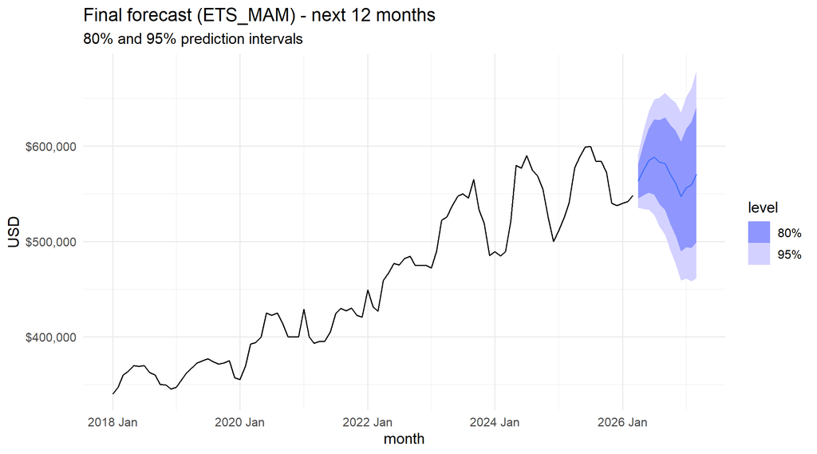

```r
p_final <- final_fc |>
  autoplot(price_ts |> filter(month >= yearmonth("2018 Jan"))) +
  labs(title = paste0("Final forecast (", winner,
                      ") - next 12 months"),
       subtitle = "80% and 95% prediction intervals",
       y = "USD") +
  scale_y_continuous(labels = scales::label_dollar())
save_png(p_final, "07_final_forecast.png", w = 10, h = 5)
p_final
```

```r
final_tbl <- final_fc |>
  hilo(level = c(80, 95)) |>
  as_tibble() |>
  mutate(
    point = .mean,
    lo80  = `80%`$lower,
    hi80  = `80%`$upper,
    lo95  = `95%`$lower,
    hi95  = `95%`$upper
  ) |>
  select(month, point, lo80, hi80, lo95, hi95)
write.csv(final_tbl, file.path(fig_dir, "final_forecast_table.csv"),
          row.names = FALSE)

final_tbl |>
  kable(digits = 0,
        caption = "Point forecast with 80% / 95% prediction intervals")
```

Point forecast with 80% / 95% prediction intervals

| month | point | lo80 | hi80 | lo95 | hi95 |
| --- | --- | --- | --- | --- | --- |
| 2026 Apr | 563324 | 544964 | 581684 | 535245 | 591403 |
| 2026 May | 575029 | 548277 | 601781 | 534116 | 615943 |
| 2026 Jun | 584844 | 551204 | 618483 | 533397 | 636291 |
| 2026 Jul | 588437 | 548986 | 627889 | 528102 | 648773 |
| 2026 Aug | 583190 | 539066 | 627314 | 515708 | 650672 |
| 2026 Sep | 581564 | 532915 | 630212 | 507163 | 655965 |
| 2026 Oct | 570230 | 518234 | 622226 | 490709 | 649751 |
| 2026 Nov | 561007 | 505822 | 616193 | 476609 | 645406 |
| 2026 Dec | 546996 | 489410 | 604582 | 458926 | 635066 |
| 2027 Jan | 556057 | 493800 | 618315 | 460842 | 651272 |
| 2027 Feb | 559510 | 493226 | 625793 | 458138 | 660881 |
| 2027 Mar | 570344 | 499155 | 641534 | 461470 | 679219 |

# 8. Conclusions and caveats

- **ETS(M,A,M)** is the most accurate model on the 12-month holdout (RMSE about $12.7k, MAPE about 2.0%), narrowly ahead of a seasonal ARIMA `(1,1,1)(0,1,1)` and well ahead of every toolbox baseline.
- The chosen model balances in-sample fit against out-of-sample accuracy on a full 12-month holdout; selection is driven by the holdout, since AICc is not comparable across model families.
- **Residuals.** The residual ACF is mostly within bounds, but a formal Ljung-Box (with degrees of freedom set to the parameter count) is significant - the 2020-2022 shock leaves some structure no smooth model fully captures. We treat this as a documented limitation and rely on prediction intervals accordingly.
- **Caveats.** Nine years of monthly data is short; the 2020 - 2022 shock is a sizeable share of the sample and may inflate the remainder term. A regime shift (rate cuts, policy change) would invalidate the point forecast quickly, which is why we report intervals as well.
- For monitoring, refit monthly as fresh observations arrive and watch the standardised residuals - sustained drift outside +/- 2 sigma would be the earliest warning that the chosen specification has expired.